# Stateless People in the World

Author

Affiliation

Miduo Sun

George Washington University

Published

May 11, 2026

## The *Invisible* Population

Most people can probably confidently claim that they have a nationality. For example, I am a citizen of the United States. But there are people in the world who simply do not have that privilege, called the **stateless population**. These people are often considered **“invisible”** because they are unseen by the governments, without the ability to legally work, marry, access healthcare, or register births. They do not have birth certificates, passports, or other forms of identification. An example of this is the one-child policy of China: Chinese families with more than one child struggled to register their additional children under the Hukou registration system. These kids were considered black-listed children (黑孩子). China does not have any publicly available data on statelessness, but this project will cover many other regions of the world. In this project, I will be answering the following questions:

- How and why did these people become invisible?
- Where in the world are stateless populations most concentrated?
- How have these populations changed over the time period of 2010-2022?

### Data source

The data covers refugees, country of origin, country of arrival, number of refugees, internally displaced persons (idps), stateless people, etc. I will be focusing on the stateless aspect of it. It covers the years 2010 to 2022. I retrieved this data from [Tidy Tuesday](https://github.com/rfordatascience/tidytuesday?tab=readme-ov-file) on Github.

**View code**

```python
import pandas as pd
df = pd.read_csv('https://raw.githubusercontent.com/rfordatascience/tidytuesday/main/data/2023/2023-08-22/population.csv')
df = df[df['coo_name'] == 'Stateless']
df.head(5)
```

|  | year | coo_name | coo | coo_iso | coa_name | coa | coa_iso | refugees | asylum_seekers | returned_refugees | idps | returned_idps | stateless | ooc | oip | hst |
| --- | --- | --- | --- | --- | --- | --- | --- | --- | --- | --- | --- | --- | --- | --- | --- | --- |
| 81 | 2010 | Stateless | STA | XXA | Egypt | ARE | EGY | 0 | 0 | 0 | 0 | 0 | 60 | 0 | NaN | NaN |
| 134 | 2010 | Stateless | STA | XXA | Argentina | ARG | ARG | 5 | 5 | 0 | 0 | 0 | 0 | 0 | NaN | NaN |
| 144 | 2010 | Stateless | STA | XXA | Armenia | ARM | ARM | 0 | 0 | 0 | 0 | 0 | 6 | 0 | NaN | NaN |
| 243 | 2010 | Stateless | STA | XXA | Australia | AUL | AUS | 347 | 30 | 0 | 0 | 0 | 0 | 0 | NaN | NaN |
| 328 | 2010 | Stateless | STA | XXA | Austria | AUS | AUT | 443 | 278 | 0 | 0 | 0 | 401 | 0 | NaN | NaN |

Not only are these stateless populations invisible to the government, they are also invisible in these datasets. In this table under the Country of Origin (coo_name) column, they are simply marked as “stateless.” We can’t tell which country they were living in, and can only see the Country of Arrival (coa_name) of these refugees and population. However, using the Country of Arrival, we can guess which country they originated from. For example, those with a Country of Arrival in Bangladesh were most likely to originate from Myanmar because of the Rohingya crisis.

## Global Statelessness

### Places Statelessness is Most Concentrated in 2022

Firstly, we will look at a global map marking which countries experience statelessness from a **low to high** level in 2022. Countries with a low level (less than 5,000) of stateless people are likely due to administrative failures, such as a parent failing to register the birth of their children. However, countries with a high level (150,000+) likely points to a greater systemic issue.

**View code**

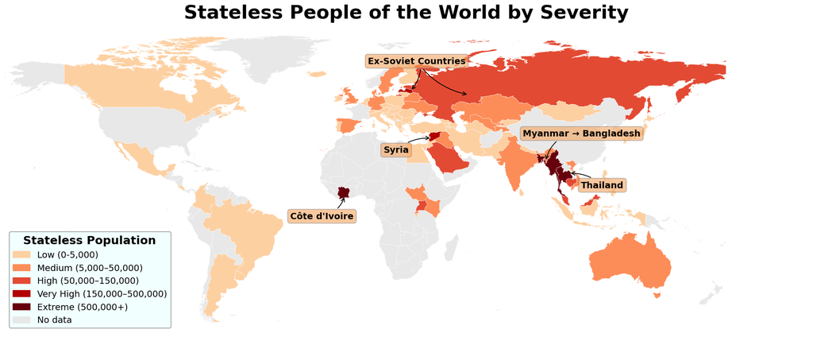

```python
import geopandas as gpd
import matplotlib.pyplot as plt
import matplotlib.patches as mpatches
import matplotlib.patheffects as pe
import pandas as pd

# Data
stateless_df = df
y2022 = (stateless_df[stateless_df['year'] == 2022]
         .groupby('coa_iso')[['coa_name', 'stateless', 'year']]
         .last().reset_index())

# Classification
bins = [0, 5000, 50000, 150000, 500000, float('inf')]
labels = ['Low (0-5,000)', 'Medium (5,000–50,000)', 'High (50,000–150,000)',
          'Very High (150,000–500,000)', 'Extreme (500,000+)']
colors = ['#fdd0a2', '#fc8d59', '#e34a33', '#b30000', '#67000d']
y2022['class'] = pd.cut(y2022['stateless'], bins=bins, labels=labels)

# Map
world = gpd.read_file('https://naturalearth.s3.amazonaws.com/50m_cultural/ne_50m_admin_0_countries.zip')
world_map = world.merge(y2022, left_on='ISO_A3', right_on='coa_iso', how='left')

color_dict = dict(zip(labels, colors))
world_map['color'] = world_map['class'].astype(str).map(color_dict).fillna('#e8e8e8')

fig, ax = plt.subplots(figsize=(18, 10))
world_map.plot(color=world_map['color'], linewidth=0.3, edgecolor='white', ax=ax)

# Legend
patches = [mpatches.Patch(color=colors[i], label=labels[i]) for i in range(len(labels))]
patches.append(mpatches.Patch(color='#e8e8e8', label='No data'))
legend = ax.legend(handles=patches, title='Stateless Population',
          loc='lower left', fontsize=14, title_fontsize=18,
          frameon=True, framealpha=0.9, edgecolor='gray', facecolor='azure')
legend.get_title().set_fontweight('bold')

# Annotations
annotations = [dict(text='Ex-Soviet Countries', xy=(55, 55), xytext=(30, 70),
         arrowprops=dict(arrowstyle='->', color='black', lw=1.2, connectionstyle='arc3,rad=0.2')),
    dict(text='',
         xy=(27, 57), xytext=(32, 70),
         arrowprops=dict(arrowstyle='->', color='black', lw=1.2, connectionstyle='arc3,rad=-0.2')),

    dict(text="Côte d'Ivoire", xy=(-5, 6), xytext=(-16, -5),
         arrowprops=dict(arrowstyle='->', color='black', lw=1.2, connectionstyle='arc3,rad=0.3')),

    dict(text='Myanmar → Bangladesh', xy=(92.5, 23), xytext=(110, 35),
         arrowprops=dict(arrowstyle='->', color='black', lw=1.2, connectionstyle='arc3,rad=0.4')),

    dict(text='Thailand',
         xy=(104, 17), xytext=(120, 10),
         arrowprops=dict(arrowstyle='->', color='black', lw=1.2, connectionstyle='arc3,rad=0.2')),

    dict(text='Syria',
         xy=(37, 34), xytext=(20, 27),
         arrowprops=dict(arrowstyle='->', color='black', lw=1.2, connectionstyle='arc3,rad=-0.2'))]

for ann in annotations:
    ax.annotate(ann['text'], xy=ann['xy'], xytext=ann['xytext'], fontsize=14, fontweight='bold',
                ha='center', arrowprops=ann['arrowprops'],
                bbox=dict(boxstyle='round,pad=0.3', facecolor='sandybrown', edgecolor='gray', alpha=0.6))

ax.set_title('Stateless People of the World by Severity', fontsize=30, fontweight='bold')
ax.set_axis_off()
ax.set_xlim(-170, 220)
ax.set_ylim(-60, 90)
plt.tight_layout()
plt.show()
```

On this map, I marked five countries or regions that have experienced very high or extreme levels of statelessness. Here is how those places saw a higher stateless population.

**Ex-Soviet states:** When the Soviet Union collapsed in 1991, millions of ethnic Russians and minorities living in newly independent states became stateless because they didn’t qualify for citizenship under the new nationality laws.

**Syria:** The Kurdish minority were denied citizenship under a 1962 census with discriminatory laws.

**Myanmar/Bangladesh**: the Rohingya Muslim minority were stripped of citizenship by Myanmar’s 1982 Citizenship Law, forcing millions to flee to Bangladesh.

**Thailand:** Ethnic minorities living in the mountainious highlands were never registered at birth, so they never received citizenship.

**Côte d’Ivoire:** After the 2002 civil war, migrants from neighboring countries who worked on cocoa farms were removed of citizenship because of strict nationality laws.

The Americas experience very low levels of statelessness, and overall, there seems to be no obvious geographic trend in where statelessness could occur.

### Top 15 Countries by Statelessness in 2022

After looking at the map, let’s look at real population numbers and how they compare with each other.

**View code**

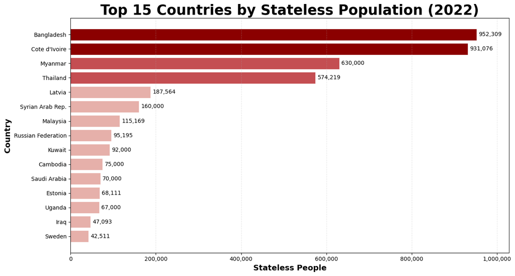

```python
import matplotlib.pyplot as plt
import matplotlib.patheffects as pe
import numpy as np

# Data
stateless_df = df[df['coo'] == 'STA']
top_countries = (stateless_df[stateless_df['year'] == 2022]
                 .groupby('coa_name')['stateless']
                 .sum()
                 .sort_values(ascending=False)
                 .head(15))

# Plot, color
fig, ax = plt.subplots(figsize=(13, 7))

colors = ['#8B0000' if i <= 1 else '#c44e52' if i < 4 else '#e6b0aa'
          for i in range(len(top_countries))]

bars = ax.barh(top_countries.index[::-1], top_countries.values[::-1],
               color=colors[::-1], edgecolor='white', linewidth=0.5)

# Annotation
for bar, val in zip(bars, top_countries.values[::-1]):
    ax.text(bar.get_width() + 5000, bar.get_y() + bar.get_height()/2,
            f'{val:,.0f}', va='center', fontsize=10, color='black')


ax.set_title('Top 15 Countries by Stateless Population (2022)', fontweight='bold', fontsize=25)
ax.set_xlabel('Stateless People', fontweight='bold', fontsize=14)
ax.set_ylabel('Country', fontweight='bold', fontsize=14)
ax.xaxis.set_major_formatter(plt.FuncFormatter(lambda x, _: f'{x:,.0f}'))
ax.grid(axis='x', linestyle='--', alpha=0.3)
ax.set_xlim(0, top_countries.max() * 1.08)
plt.tight_layout()
plt.show()
```

**Bangladesh** and **Cote d’Ivoire** are the two countries with the highest stateless population at nearly one million people. Third and Fourth are **Myanmar** and **Thailand**, two neighboring countries with approximately 600,000 stateless people each. **Latvia**, a developed Eastern European country, is in the top 5 which is quite interesting and surprising. There are multiple other developed countries in the list, such as **Russia, Saudi Arabia, Estonia, and Sweden**. It seems like statelessness is **not** correlated with how *developed* a country is.

### Stateless Populations Map, 2010-2022

Instead of focusing on one specific year, let’s take a look at how statelessness has changed throughout the time period of 2010 to 2022. For example, *has Bangladesh always had that much stateless people, or did it increase/decrease over time?*

**View code**

```python
import plotly.express as px
import pandas as pd
import plotly.io as pio
pio.renderers.default = "plotly_mimetype+notebook"

stateless_df = df[df['coo_name'] == 'Stateless'].copy()
stateless_df = stateless_df.sort_values('year').reset_index(drop=True)

fig = px.choropleth(stateless_df, locations='coa_iso', color='stateless', hover_name='coa_name',
                    hover_data={'year':True, 'stateless':':,', 'coa_iso':False},
                    color_continuous_scale='Reds', title='Stateless Populations Over Time, 2010-2022',
                    labels={'stateless': 'Stateless Population'}, animation_frame='year')

fig.update_layout(height=600, geo=dict(showframe=False, showcoastlines=True, projection_type='natural earth'),
    coloraxis_colorbar=dict(title='Stateless Population'),
    title_font=dict(size=25, family='Arial Black'),
    title_x=0.5, margin=dict(l=0, r=0, t=40, b=0))

fig.show()
```

[interactive chart not shown]

At first glance, there doesn’t seem to be stark changes to the map. But, to answer the Bangladesh question above: Interestingly, Bangladesh had no data/insignificant stateless population until the year 2017. All of a sudden, it jumped up to having more than **900,000** stateless people. If you’re curious about why this happened, I will analyze this further below!

**Myanmar** has populations also experiencing high levels of statelessness, but slightly decreased over time.

Population numbers in **Côte d’Ivoire** has had more than 700,000 to 900,000 stateless people for more than a decade. It is the only country in West Africa that has data.

A small detail I noticed in Europe: the only country in Europe that sticks out to me is **Latvia**, with higher statelessness than any other European country.

**The three visualizations above led me to be curious and dive further into two regions of the world: South and Southeast Asia (Myanmar, Bangladesh, and Thailand) and the Ex-Soviet Eastern European countries.**

## The South and Southeast Asia Statelessness Crisis

### A Comparison Between 2015 and 2020

As seen in the maps above, a major hub of statelessness was concentrated in three neighboring countries: Myanmar, Bangladesh, and Thailand.

**View code**

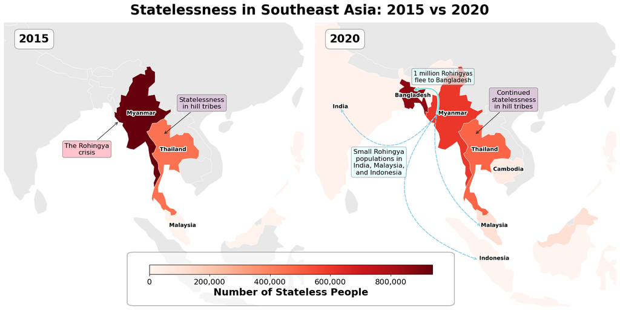

```python
import matplotlib.pyplot as plt
import geopandas as gpd
import pandas as pd
import matplotlib.patheffects as pe
from matplotlib.patches import FancyBboxPatch

# Data
stateless_df = df[df['coo'] == 'STA'].copy()

southeast_asia = ['Myanmar', 'Thailand', 'Vietnam', 'Bangladesh', 'Malaysia',
                  'Indonesia', 'Cambodia', 'Laos', 'Philippines', 'India', 'Pakistan']

sea_df = stateless_df[stateless_df['coa_name'].isin(southeast_asia)]

y2015 = sea_df[sea_df['year'] == 2015]
y2020 = sea_df[sea_df['year'] == 2020]

world = gpd.read_file('https://naturalearth.s3.amazonaws.com/110m_cultural/ne_110m_admin_0_countries.zip')
map_2015 = world.merge(y2015[['coa_iso', 'stateless']], left_on='ISO_A3', right_on='coa_iso', how='left')
map_2020 = world.merge(y2020[['coa_iso', 'stateless']], left_on='ISO_A3', right_on='coa_iso', how='left')

# Plot
vmin = 0
vmax = max(y2015['stateless'].max(), y2020['stateless'].max())
fig, axes = plt.subplots(1, 2, figsize=(16, 8))

for ax, data, year in zip(axes, [map_2015, map_2020], [2015, 2020]):
    data.plot(color='#e8e8e8', linewidth=0.5, edgecolor='white', ax=ax)
    data[data['stateless'].notna()].plot(
        column='stateless', cmap='Reds', linewidth=0.5, edgecolor='white',
        ax=ax, vmin=vmin, vmax=vmax)
    ax.set_xlim(75, 122)
    ax.set_ylim(-8, 35)
    ax.set_axis_off()

# Legend
sm = plt.cm.ScalarMappable(cmap='Reds', norm=plt.Normalize(vmin=vmin, vmax=vmax))
sm.set_array([])
cbar = fig.colorbar(sm, ax=axes, orientation='horizontal', fraction=0.08, pad=0.04, location='bottom', shrink=0.7, aspect=30)
cbar.set_label('Number of Stateless People', fontsize=18, fontweight='bold')
cbar.set_ticks([0, 200000, 400000, 600000, 800000])
cbar.ax.xaxis.set_major_formatter(plt.FuncFormatter(lambda x, _: f'{x:,.0f}'))
cbar.ax.tick_params(labelsize=14)
cbar.ax.set_position([0.22, 0.12, 0.5, 0.03])
pos = cbar.ax.get_position()
fancy = FancyBboxPatch((pos.x0 - 0.00, pos.y0 - 0.09), pos.width + 0.00, pos.height + 0.12,
    boxstyle='round,pad=0.01', facecolor='white', edgecolor='gray', linewidth=1.5,
    transform=fig.transFigure, zorder=2, alpha=0.6)
fig.add_artist(fancy)
cbar.ax.set_zorder(3)

# Labels
labels2015 = {'Myanmar': (96.5, 21), 'Thailand': (101.5, 15.5),'Malaysia': (103, 4) }

labels2020 = {'Myanmar': (96.5, 21), 'Bangladesh': (90.3, 23.7), 'Thailand': (101.5, 15.5), 'India': (79, 22),
              'Indonesia': (103, -1), 'Malaysia': (103, 4), 'Cambodia': (105.2, 12.5), }

for ax, data, year, label_dict in zip(axes, [map_2015, map_2020], [2015, 2020], [labels2015, labels2020]):
    for country, (lon, lat) in label_dict.items():
        ax.annotate(country, xy=(lon, lat), fontsize=10, fontweight='bold',
                    ha='center', color='black',
                    path_effects=[pe.withStroke(linewidth=3, foreground='white')])
    if year == 2015:
        ax.text(0.05, 0.93, '2015', transform=ax.transAxes,
                fontsize=20, fontweight='bold', color='black',
                bbox=dict(boxstyle='round,pad=0.4', facecolor='white', edgecolor='gray', alpha=0.8))
        ax.annotate('The Rohingya\ncrisis', xy=(93, 20), xytext=(88, 15), fontsize=12, ha='center',
            arrowprops=dict(arrowstyle='->', color='black', lw=0.8),
            bbox=dict(boxstyle='round,pad=0.3', facecolor='lightpink', edgecolor='gray', alpha=0.8))
        ax.annotate('Statelessness\nin hill tribes', xy=(100, 18), xytext=(106, 22), fontsize=12, ha='center',
                arrowprops=dict(arrowstyle='->', color='black', lw=0.8),
                bbox=dict(boxstyle='round,pad=0.3', facecolor='thistle', edgecolor='gray', alpha=0.8))
    if year == 2020:
        ax.text(0.05, 0.93, '2020', transform=ax.transAxes,
                fontsize=20, fontweight='bold', color='black',
                bbox=dict(boxstyle='round,pad=0.4', facecolor='white', edgecolor='gray', alpha=0.8))
        ax.annotate('', xy=(90.1, 24.6),xytext=(94, 21),
                    arrowprops=dict(arrowstyle='->', color='white', lw=4, connectionstyle='arc3,rad=0.9'))
        ax.annotate('', xy=(90.3, 24.7), xytext=(94, 21),
                arrowprops=dict(arrowstyle='->', color='turquoise', lw=1.5, connectionstyle='arc3,rad=0.9'), )
        ax.annotate('Continued\nstatelessness\nin hill tribes',
                xy=(100, 18),
                xytext=(106, 22),
                fontsize=12, ha='center',
                arrowprops=dict(arrowstyle='->', color='black', lw=0.8),
                bbox=dict(boxstyle='round,pad=0.3', facecolor='thistle', edgecolor='gray', alpha=0.8))
        # India arrow
        ax.annotate('', xy=(79, 22),
                xytext=(94, 21),
                arrowprops=dict(arrowstyle='->', color='skyblue', linestyle='dashed', lw=1.5, connectionstyle='arc3,rad=-0.7'))
        # Malaysia arrow
        ax.annotate('', xy=(101, 4), xytext=(94, 21),
                arrowprops=dict(arrowstyle='->', color='skyblue', linestyle='dashed', lw=1.5, connectionstyle='arc3,rad=0.3'))
        # Indonesia arrow
        ax.annotate('', xy=(100.5, -1), xytext=(94, 21),
                arrowprops=dict(arrowstyle='->', color='skyblue', linestyle='dashed', lw=1.5, connectionstyle='arc3,rad=0.7'))
        ax.annotate('1 million Rohingyas\nflee to Bangladesh', xy=(93, 20), xytext=(95, 26), fontsize=11, ha='center',
                bbox=dict(boxstyle='round,pad=0.3', facecolor='lightcyan', edgecolor='gray', alpha=0.7))
        ax.annotate('Small Rohingya\npopulations in\nIndia, Malaysia,\nand Indonesia',
                xy=(93, 30), xytext=(85, 12), fontsize=12, ha='center',
                bbox=dict(boxstyle='round,pad=0.3', facecolor='lightcyan', edgecolor='gray', alpha=0.6))

plt.suptitle('Statelessness in Southeast Asia: 2015 vs 2020', fontsize=25, fontweight='bold', y=0.98)
plt.tight_layout()
plt.show()
```

There were some noticeable changes in Southeast and South Asia between 2015 and 2020. In **2015**, the only two countries with noticeable numbers of stateless populations were Myanmar and Thailand. Myanmar had approximately 900,000 stateless people and Thailand had approximately 400,000.

### Stateless People in Myanmar: Rohingyas

Since **1982**, the Rohingyas were not allowed to gain citizenship even though they were born and raised in Myanmar due to a discriminatory law.

Between **2015 and 2020**, the government of Myanmar has even gone as far as launching **militarized** attacks on Rohingya communities and killed thousands. This ‘ethnic cleansing’ has forced over a million of Rohingyas into **refugee** status, fleeing into other South or Southeast Asian countries.

The decrease in stateless people that we see in Myanmar in **2020** is not a result of the Rohingyas gaining citizenship. This is because approximately 1 million of them fled West to their neighboring country, **Bangladesh**. Thousands of others also fled by boat into **India, Malaysia, and Indonesia**. That is the reason we see a sudden increase in statelessness populations through South and Southeast Asia by year 2020.

### Stateless People in Thailand: Hill Tribes

The Thai government has limited Rohingya refugees from Myanmar to come into their country not only because they see them as illegal immigrants, but also because they are dealing with their own stateless crisis. More than **500,000 people** who live in the hill tribes of Thailand, the high mountainious regions of the country, are registered as stateless. They lack the access to vote, use public services, and travel. Though there was not a clear improvement in statelessness between 2015 and 2020, there has been progress made in 2025 towards acquiring Thai nationality.

[figure not shown]

Meepia was formerly stateless and received her new Thai identification card in Chiang Mai, Thailand in 2024.

## Statelessness in Ex-Soviet Union Countries

### Most Concentrated Ex-Soviet Countries in 2022

Next, we will switch up the region and analyze the Eastern European and Central Asian Ex-Soviet countries. Though there are significantly less stateless people in these countries, if we add up all the Ex-Soviet countries combined, here is the total number of stateless people:

**View code**

```python
soviet_df = stateless_df[stateless_df['coa_name'].isin(soviet_data)].copy()
print(soviet_df[soviet_df['year'] == 2022]['stateless'].sum())
```

```
419883
```

This is quite a large amount. Let’s analyze this further and also see why Latvia stands out the most and why statelessness exists there.

**View code**

```python
import folium
import geopandas as gpd
import pandas as pd

# Data
soviet_data = ['Russian Federation', 'Ukraine', 'Estonia', 'Latvia', 'Lithuania', 'Belarus',
               'Moldova', 'Armenia', 'Azerbaijan', 'Georgia', 'Kazakhstan',
               'Kyrgyzstan', 'Tajikistan', 'Turkmenistan', 'Uzbekistan']

soviet_shape = ['Russia', 'Ukraine', 'Estonia', 'Latvia', 'Lithuania', 'Belarus',
                'Moldova', 'Armenia', 'Azerbaijan', 'Georgia', 'Kazakhstan',
                'Kyrgyzstan', 'Tajikistan', 'Turkmenistan', 'Uzbekistan']

y2022 = soviet_df[soviet_df['year'] == 2022][['coa_iso', 'coa_name', 'stateless', 'year']]

world = gpd.read_file('https://naturalearth.s3.amazonaws.com/50m_cultural/ne_50m_admin_0_countries.zip')
merged = world.merge(y2022, left_on='ISO_A3', right_on='coa_iso', how='left')

soviet_map = merged[merged['NAME'].isin(soviet_shape)]
soviet_map['lon'] = soviet_map['LABEL_X']
soviet_map['lat'] = soviet_map['LABEL_Y']

# Map
m = folium.Map(location=[50, 60], zoom_start=3, tiles='CartoDB positron')

folium.Choropleth(geo_data=soviet_map.__geo_interface__, data=y2022,
    columns=['coa_iso', 'stateless'], key_on='feature.properties.ISO_A3',
    fill_color='YlOrRd', fill_opacity=0.7, line_opacity=0.5,
    nan_fill_color='#e8e8e8', legend_name='Stateless Population').add_to(m)

# Circle marker
for _, row in soviet_map.dropna(subset=['stateless']).iterrows():
    stateless = int(row['stateless'])
    country = row['coa_name']
    year = int(row['year'])
    radius = max(5, (stateless / 10000) ** 0.5 * 3)

    folium.CircleMarker(location=[row['lat'], row['lon']], radius=radius,
        color='#c0392b', fill=True, fill_color='#e74c3c', fill_opacity=0.6,
        tooltip=f'{country}: {stateless:,} stateless ({year})',
        popup=folium.Popup(f'''<b>{country}</b><br>
            Stateless population: <b>{stateless:,}</b><br>
            Most recent year: {year}''', max_width=200)).add_to(m)

m
```

[interactive chart not shown]

As we seen above, there are still thousands or more of people in each country that are still stateless. This was a result of many people being born in a country, the Soviet Union, which didn’t exist anymore. For example, a man with citizenship of the Soviet Union moved to present-day Uzbekistan. After the collapse of the Soviet Union, he obviously was not a Soviet citizen, and the Uzbek government did not recognize him as a citizen either. This was the cause of statelessness in many countries in this region.

#### Why Latvia?

Latvia sticks out the most with **187,564 stateless people**, despite being a small country. In fact, that was 10% of its population. This was because Latvia did not automatically grant citizenship to people who were not Latvian citizens before the Soviet Union. Many Russian-speaking people who moved to Latvia during the Soviet era were excluded from citizenship. However, this has changed over time as I have analyzed below.

### Changes in Ex-Soviet Union Countries Over Time

In this visualization, we will be looking at whether the stateless numbers increased or decreased any time. I chose the top 6 Soviet countries that had the highest stateless populations.

**View code**

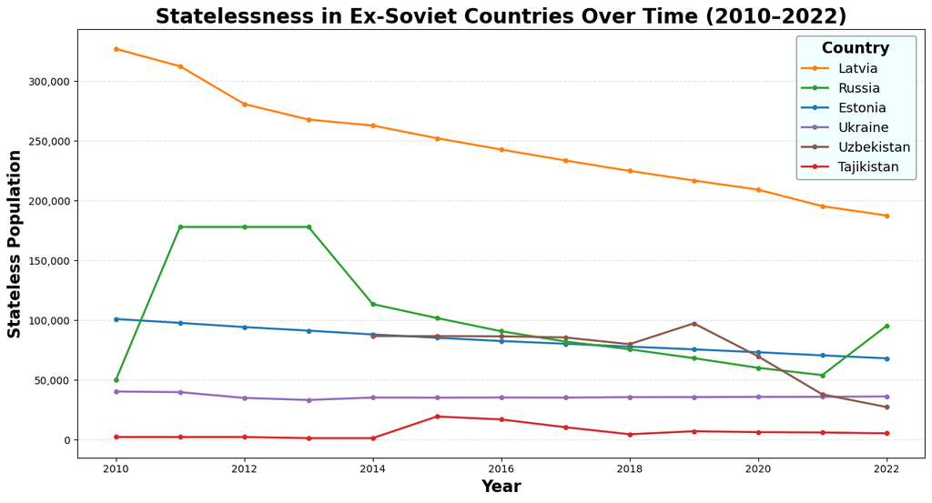

```python
import matplotlib.pyplot as plt

# Data
soviet_data = ['Russian Federation', 'Ukraine', 'Estonia', 'Latvia',
               'Tajikistan', 'Uzbekistan']

soviet_df = stateless_df[stateless_df['coa_name'].isin(soviet_data)].copy()
soviet_df['coa_name'] = soviet_df['coa_name'].replace('Russian Federation', 'Russia')

# Plot
fig, ax = plt.subplots(figsize=(13, 7))
line_handles = {}
for country, group in soviet_df.sort_values('year').groupby('coa_name'):
    line, = ax.plot(group['year'], group['stateless'], marker='o', markersize=4,
                    linewidth=2, label=country)
    final_val = group.sort_values('year')['stateless'].iloc[-1]
    line_handles[country] = (line, final_val)

# sort legend by final value high to low
sorted_lines = sorted(line_handles.items(), key=lambda x: x[1][1], reverse=True)
handles = [v[0] for _, v in sorted_lines]
labels = [k for k, _ in sorted_lines]

# Legend
legend = ax.legend(handles=handles, labels=labels, fontsize=13,title='Country',
          title_fontsize=15, bbox_to_anchor=(0.84, 1), loc='upper left',
          frameon=True, framealpha=0.9, edgecolor='gray', facecolor='azure')
legend.get_title().set_fontweight('bold')

ax.set_title('Statelessness in Ex-Soviet Countries Over Time (2010–2022)',
             fontsize=20, fontweight='bold')
ax.set_xlabel('Year', fontsize=16, fontweight='bold')
ax.set_ylabel('Stateless Population', fontsize=16, fontweight='bold')
ax.yaxis.set_major_formatter(plt.FuncFormatter(lambda x, _: f'{x:,.0f}'))
ax.grid(axis='y', linestyle='--', alpha=0.4)
plt.tight_layout()
plt.show()
```

In **Latvia**, statelessness decreased over time as people became naturalized becoming Latvian citizens, and as the older generation passed away.

For **Russia**, there was a clear decrease in statelessness between the years 2013 and 2021. There was a jump from 2021 to 2022, likely due to Russia tightening its legislation on citizenship since the invasion of Ukraine.

**Tajikistan** likely had an increase in statelessness in 2015 not because of Soviet collapse, but because of Afghan refugees entering the country.

[figure not shown]

Adolat, mother of three boys, was born in Tajikistan right before the Soviet Union collapsed in 1991. She lived most of her life stateless and in constant stress because her parents could not afford the documents fee. She received her Tajikistan passport in 2022.

## Conclusion

We learned that where statelessness occurs is not necessarily correlated with region or how developed a country is. Countries all across the world can experience statelessness, often because of two main reasons: *discrimination* and *conflicts in nationality laws*. For example, the Rohingyas faced discrimination in Myanmar for being a Muslim ethnic minority. They were denied citizenship since 1982 because of purposeful discrimination, and a million fled over to Bangladesh and other countries because of violent repression from the government. Ex-Soviet Union countries faced struggles with nationality laws after the Soviet Union collapsed, because no country would recognize them as citizens.

While both cases involve governments failing to recognize their own residents as citizens, the experiences of stateless people in these two regions are extremely different. In ex-Soviet states, stateless individuals (mostly ethnic Russians) continue to live in the same country they have always lived in, with restricted but relatively stable lives. They can often still work and access basic services, just without full political rights. In Southeast Asia, statelessness is more dangerous. The Rohingyas were actively persecuted, facing mass killings and rape, and were forced to flee across borders. Thailand’s hill tribes were quietly excluded and trapped in poverty. They are unable to access education or healthcare simply because they were never registered at birth. The main contrast is that Soviet statelessness is a political inconvenience that governments have been slow to fix, while Southeast Asian statelessness is rooted in ethnic discrimination and genocide. However, what all stateless people struggle with is legally working, going to school, purchasing property, voting, or travelling freely—something that we may take for granted in our daily lives.

[figure not shown]